# Numpy_Assignment_2

## File : Numpy Assignment 2

### Topic : Exercise 1-14

#### Submitted by: Anoop V H

##### Version : 1.0

##### Date's:

##### Start date of assignment : Feb 13, 2020

##### First Submission date : Feb 16,2020

```python
import numpy as np
import scipy.linalg as la
import matplotlib.pyplot as plt
```

## 1. Choose a value and set the variable x to that value

```python
x=4
```

## 2. What is command to compute the square of x? Its cube?

```python
x_square=x**2
x_cube=x**3

print("Square of ",x,"is :",x_square)

print("Cube of ",x,"is :",x_cube)
```

```
Square of  4 is : 16
Cube of  4 is : 64
```

### 3. Choose an angle θ and set the variable theta to its value (a number).

```python
theta=90
```

### 4. What is sinθ? cosθ? Angles can be measured in degrees or radians. Which of these are being used ?

```python
print("sine of ",theta," radians is :",np.sin(theta))

print("Cos of ",theta," radians is :",np.cos(theta))
```

```
sine of  90  radians is : 0.8939966636005579
Cos of  90  radians is : -0.4480736161291701
```

### 5. Use the np.linspace function to create a row vector called meshPoints containing exactly 500 values with values evenly spaced between -1 and 1.

```python
meshPoints=np.linspace(-1,1,500)
meshPoints
```

```
array([-1.        , -0.99599198, -0.99198397, -0.98797595, -0.98396794,
       -0.97995992, -0.9759519 , -0.97194389, -0.96793587, -0.96392786,
       -0.95991984, -0.95591182, -0.95190381, -0.94789579, -0.94388778,
       -0.93987976, -0.93587174, -0.93186373, -0.92785571, -0.9238477 ,
       -0.91983968, -0.91583166, -0.91182365, -0.90781563, -0.90380762,
       -0.8997996 , -0.89579158, -0.89178357, -0.88777555, -0.88376754,
       -0.87975952, -0.8757515 , -0.87174349, -0.86773547, -0.86372745,
       -0.85971944, -0.85571142, -0.85170341, -0.84769539, -0.84368737,
       -0.83967936, -0.83567134, -0.83166333, -0.82765531, -0.82364729,
       -0.81963928, -0.81563126, -0.81162325, -0.80761523, -0.80360721,
       -0.7995992 , -0.79559118, -0.79158317, -0.78757515, -0.78356713,
       -0.77955912, -0.7755511 , -0.77154309, -0.76753507, -0.76352705,
       -0.75951904, -0.75551102, -0.75150301, -0.74749499, -0.74348697,
       -0.73947896, -0.73547094, -0.73146293, -0.72745491, -0.72344689,
       -0.71943888, -0.71543086, -0.71142285, -0.70741483, -0.70340681,
       -0.6993988 , -0.69539078, -0.69138277, -0.68737475, -0.68336673,
       -0.67935872, -0.6753507 , -0.67134269, -0.66733467, -0.66332665,
       -0.65931864, -0.65531062, -0.65130261, -0.64729459, -0.64328657,
       -0.63927856, -0.63527054, -0.63126253, -0.62725451, -0.62324649,
       -0.61923848, -0.61523046, -0.61122244, -0.60721443, -0.60320641,
       -0.5991984 , -0.59519038, -0.59118236, -0.58717435, -0.58316633,
       -0.57915832, -0.5751503 , -0.57114228, -0.56713427, -0.56312625,
       -0.55911824, -0.55511022, -0.5511022 , -0.54709419, -0.54308617,
       -0.53907816, -0.53507014, -0.53106212, -0.52705411, -0.52304609,
       -0.51903808, -0.51503006, -0.51102204, -0.50701403, -0.50300601,
       -0.498998  , -0.49498998, -0.49098196, -0.48697395, -0.48296593,
       -0.47895792, -0.4749499 , -0.47094188, -0.46693387, -0.46292585,
       -0.45891784, -0.45490982, -0.4509018 , -0.44689379, -0.44288577,
       -0.43887776, -0.43486974, -0.43086172, -0.42685371, -0.42284569,
       -0.41883768, -0.41482966, -0.41082164, -0.40681363, -0.40280561,
       -0.3987976 , -0.39478958, -0.39078156, -0.38677355, -0.38276553,
       -0.37875752, -0.3747495 , -0.37074148, -0.36673347, -0.36272545,
       -0.35871743, -0.35470942, -0.3507014 , -0.34669339, -0.34268537,
       -0.33867735, -0.33466934, -0.33066132, -0.32665331, -0.32264529,
       -0.31863727, -0.31462926, -0.31062124, -0.30661323, -0.30260521,
       -0.29859719, -0.29458918, -0.29058116, -0.28657315, -0.28256513,
       -0.27855711, -0.2745491 , -0.27054108, -0.26653307, -0.26252505,
       -0.25851703, -0.25450902, -0.250501  , -0.24649299, -0.24248497,
       -0.23847695, -0.23446894, -0.23046092, -0.22645291, -0.22244489,
       -0.21843687, -0.21442886, -0.21042084, -0.20641283, -0.20240481,
```

[output cut: 45 more lines]

```
        0.70340681,  0.70741483,  0.71142285,  0.71543086,  0.71943888,
        0.72344689,  0.72745491,  0.73146293,  0.73547094,  0.73947896,
        0.74348697,  0.74749499,  0.75150301,  0.75551102,  0.75951904,
        0.76352705,  0.76753507,  0.77154309,  0.7755511 ,  0.77955912,
        0.78356713,  0.78757515,  0.79158317,  0.79559118,  0.7995992 ,
        0.80360721,  0.80761523,  0.81162325,  0.81563126,  0.81963928,
        0.82364729,  0.82765531,  0.83166333,  0.83567134,  0.83967936,
        0.84368737,  0.84769539,  0.85170341,  0.85571142,  0.85971944,
        0.86372745,  0.86773547,  0.87174349,  0.8757515 ,  0.87975952,
        0.88376754,  0.88777555,  0.89178357,  0.89579158,  0.8997996 ,
        0.90380762,  0.90781563,  0.91182365,  0.91583166,  0.91983968,
        0.9238477 ,  0.92785571,  0.93186373,  0.93587174,  0.93987976,
        0.94388778,  0.94789579,  0.95190381,  0.95591182,  0.95991984,
        0.96392786,  0.96793587,  0.97194389,  0.9759519 ,  0.97995992,
        0.98396794,  0.98797595,  0.99198397,  0.99599198,  1.        ])
```

### 6. What expression will yield the value of the 53th element of meshPoints?

### What is this value?

```python
meshPoints[52] #52 th index will give you the value of 53rd element in the meshpoints
```

```
-0.7915831663326653
```

### 7. Produce a plot of a sinusoid on the interval [−1,1] using the command

#### plt.plot(meshPoints,np.sin(2*pi*meshPoints))

### Please save this plot as a jpeg (.jpg) file and send it along with your work.

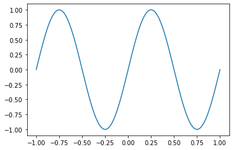

```python
plt.plot(meshPoints,np.sin(2*np.pi*meshPoints))

plt.savefig('sinusoid.jpeg', dpi=200) #saving the plot in the same directory with file
# name as "sinusoid.jpeg"
```

# Vector and matrix operations: Exercise (5 points)

```python
# Define the following vectors and matrices:

vec1 = np.array([ -1., 4., -9.])
mat1 = np.array([[ 1., 3., 5.], [7., -9., 2.], [4., 6., 8. ]])
```

## 1. You can multiply vectors by constants. Compute

```python
vec2 = (np.pi/4) * vec1

print(vec2)
```

```
[-0.78539816  3.14159265 -7.06858347]
```

## 2. The cosine function can be applied to a vector to yield a vector of cosines.

### Compute

```python
vec2 = np.cos(vec2)
print(vec2)
```

```
[ 0.70710678 -1.          0.70710678]
```

## 3. You can add vectors and multiply by scalars. Compute

### vec3 = vec1 + 2 * vec2

```python
vec3 = vec1 + 2 * vec2

print(vec3)
```

```
[ 0.41421356  2.         -7.58578644]
```

## 4. The Euclidean norm of a matrix or a vector is available using

## la.norm.

#### Compute la.norm(vec3)

```python
la.norm(vec3)
```

```
7.855935892848037
```

### 5. You can do row-column matrix multiplication. Compute the product of

## mat1 and vec3 and set vec4 equal to the result.

```python
vec4=np.matmul(mat1,vec3)

print(vec4)
```

```
[-31.51471863 -30.27207794 -47.02943725]
```

### 6. Compute the transpose of mat1.

```python
np.transpose(mat1)
```

```
array([[ 1.,  7.,  4.],
       [ 3., -9.,  6.],
       [ 5.,  2.,  8.]])
```

## 7. Compute the determinant of mat1.

```python
la.det(mat1)
```

```
161.99999999999997
```

### 8. Compute the trace of mat1.

```python
np.trace(mat1)
```

```
0.0
```

### 9. Find the smallest element in vec1.

```python
np.min(mat1)
```

```
-9.0
```

### 10. What function would you use to find the value of j so that vec1[j] is equal to

### the smallest element in vec1?

```python
min_value=vec1.min()

j=np.where(vec1==min_value)

print(j)
```

```
(array([2], dtype=int64),)
```

#### 11. What expression would you use to find the smallest element of the matrix mat1?

```python
np.min(mat1)
```

```
-9.0
```

## 12. The function np.random.rand can be used to construct and fill vectors and matrices with random numbers.

## Use the help facility in Python to learn how to construct a 10 × 10 matrix named M filled with random numbers.

```python
M=np.random.rand(10,10)

print(M)
```

```
[[0.32731267 0.92023102 0.80056126 0.16447577 0.02907942 0.62729238
  0.81798833 0.25490281 0.69026986 0.27085673]
 [0.61463103 0.69163937 0.89434915 0.83943579 0.68658746 0.08635046
  0.05882773 0.26173822 0.162206   0.63401687]
 [0.61749913 0.03128207 0.76541673 0.91421867 0.31734695 0.98824456
  0.04687037 0.3003668  0.8624083  0.87579551]
 [0.76729186 0.53607115 0.93822866 0.22601216 0.7604492  0.02094557
  0.67129988 0.42460381 0.5635542  0.64937396]
 [0.44990846 0.71371492 0.37117169 0.28718608 0.36549156 0.61149046
  0.95637434 0.85169326 0.74713006 0.83455717]
 [0.44437667 0.94770917 0.87915353 0.13309107 0.35486179 0.40661494
  0.45751974 0.83747071 0.83917441 0.98866736]
 [0.66573718 0.24854674 0.81763015 0.02534702 0.61160358 0.96228952
  0.83670238 0.93554721 0.16913259 0.33926839]
 [0.86120074 0.55306459 0.80577676 0.0298402  0.29425166 0.35670276
  0.44627582 0.77062689 0.06898243 0.72037337]
 [0.47034622 0.77419119 0.11377513 0.20272645 0.12757367 0.96308208
  0.11780165 0.97078684 0.94973003 0.33966259]
 [0.25942082 0.01544744 0.32744899 0.2230752  0.10913426 0.0796813
  0.82864257 0.53311936 0.90179114 0.75812592]]
```

## 13. The colon and index notation can also be used to refer to a subset of elements of the array. With the start:increment:finish notation, we can refer to a range of indices.

```python
##
```

## 14. What commands would be needed to generate the four 5×5 sub-matrices of M in the upper left quarter MUL, the upper right quarter MUR, the lower left quarter MLL, and the lower right quarter MLR.

```python
MUL=M[:5,:5]  # selecting the upper half left
MUR=M[:5,5:10]  #selecting the upper right
MLL=M[5:10,:5]
MLR=M[5:10,5:10]

MUL,MUR,MLL,MLR
```

```
(array([[0.32731267, 0.92023102, 0.80056126, 0.16447577, 0.02907942],
        [0.61463103, 0.69163937, 0.89434915, 0.83943579, 0.68658746],
        [0.61749913, 0.03128207, 0.76541673, 0.91421867, 0.31734695],
        [0.76729186, 0.53607115, 0.93822866, 0.22601216, 0.7604492 ],
        [0.44990846, 0.71371492, 0.37117169, 0.28718608, 0.36549156]]),
 array([[0.62729238, 0.81798833, 0.25490281, 0.69026986, 0.27085673],
        [0.08635046, 0.05882773, 0.26173822, 0.162206  , 0.63401687],
        [0.98824456, 0.04687037, 0.3003668 , 0.8624083 , 0.87579551],
        [0.02094557, 0.67129988, 0.42460381, 0.5635542 , 0.64937396],
        [0.61149046, 0.95637434, 0.85169326, 0.74713006, 0.83455717]]),
 array([[0.44437667, 0.94770917, 0.87915353, 0.13309107, 0.35486179],
        [0.66573718, 0.24854674, 0.81763015, 0.02534702, 0.61160358],
        [0.86120074, 0.55306459, 0.80577676, 0.0298402 , 0.29425166],
        [0.47034622, 0.77419119, 0.11377513, 0.20272645, 0.12757367],
        [0.25942082, 0.01544744, 0.32744899, 0.2230752 , 0.10913426]]),
 array([[0.40661494, 0.45751974, 0.83747071, 0.83917441, 0.98866736],
        [0.96228952, 0.83670238, 0.93554721, 0.16913259, 0.33926839],
        [0.35670276, 0.44627582, 0.77062689, 0.06898243, 0.72037337],
        [0.96308208, 0.11780165, 0.97078684, 0.94973003, 0.33966259],
        [0.0796813 , 0.82864257, 0.53311936, 0.90179114, 0.75812592]]))
```